# M03-2: Data Visualization-Application Assignment

Author

Amir Alnajjar

Published

May 9, 2026

```r
# Calling required libraries
library(tidyverse)
library(ggrepel)
library(ggthemes)
library(scales)
library(plotly)
library(lattice)
library(GGally)
```

```r
# Calling the wooldridge library containing the attend dataset
library(wooldridge)
df <- attend
df <- as_tibble(df)
head(df)
```

```
# A tibble: 6 × 11
  attend termGPA priGPA   ACT final atndrte hwrte frosh  soph missed stndfnl
   <int>   <dbl>  <dbl> <int> <int>   <dbl> <dbl> <int> <int>  <int>   <dbl>
1     27    3.19   2.64    23    28    84.4 100       0     1      5  0.473
2     22    2.73   3.52    25    26    68.8  87.5     0     0     10  0.0525
3     30    3      2.46    24    30    93.8  87.5     0     0      2  0.893
4     31    2.04   2.61    20    27    96.9 100       0     1      1  0.263
5     32    3.68   3.32    23    34   100   100       0     1      0  1.73
6     29    3.23   2.93    26    25    90.6 100       0     1      3 -0.158
```

# 1 Question 1. GT table

```r
library(gt)

df %>%
  gt() %>%
  #Rename columns
  cols_label(
    termGPA = "Term GPA",
    priGPA = "Prior Term GPA",
    atndrte = "Attendance Rate",
    hwrte = "Homework Turn-in rate",
    frosh = "Freshman",
    soph = "Sophomore"
  ) %>%
  #adding table borders and colors
  tab_options(
    table.border.top.style = "solid",
    table.border.top.color = "blue",
    table.border.bottom.style = "solid",
    table.border.bottom.color = "blue"
  )%>%
  opt_stylize(style = 6, color = "blue") %>%
   #formating the attendance rate column into a percentage
  fmt_percent(
    columns = atndrte, decimals = 1,
    scale_values = FALSE)%>%
   fmt_number(
    columns = c(termGPA, priGPA),decimals = 1
  )%>%
  #aligning all columns labels to center
  tab_style(
    style = cell_text(weight = "bold", align = "center"),
    locations = cells_column_labels(everything())
  )
```

| attend | Term GPA | Prior Term GPA | ACT | final | Attendance Rate | Homework Turn-in rate | Freshman | Sophomore | missed | stndfnl |
| --- | --- | --- | --- | --- | --- | --- | --- | --- | --- | --- |
| 27 | 3.2 | 2.6 | 23 | 28 | 84.4% | 100.0 | 0 | 1 | 5 | 0.47268906 |
| 22 | 2.7 | 3.5 | 25 | 26 | 68.8% | 87.5 | 0 | 0 | 10 | 0.05252101 |
| 30 | 3.0 | 2.5 | 24 | 30 | 93.8% | 87.5 | 0 | 0 | 2 | 0.89285713 |
| 31 | 2.0 | 2.6 | 20 | 27 | 96.9% | 100.0 | 0 | 1 | 1 | 0.26260504 |
| 32 | 3.7 | 3.3 | 23 | 34 | 100.0% | 100.0 | 0 | 1 | 0 | 1.73319328 |
| 29 | 3.2 | 2.9 | 26 | 25 | 90.6% | 100.0 | 0 | 1 | 3 | -0.15756303 |
| 30 | 1.5 | 1.9 | 21 | 10 | 93.8% | 75.0 | 1 | 0 | 2 | -3.30882359 |
| 26 | 2.0 | 2.1 | 22 | 34 | 81.2% | 100.0 | 0 | 1 | 6 | 1.73319328 |
| 24 | 2.2 | 2.1 | 24 | 26 | 75.0% | 100.0 | 1 | 0 | 8 | 0.05252101 |
| 29 | 3.0 | 2.7 | 21 | 26 | 90.6% | 100.0 | 0 | 1 | 3 | 0.05252101 |
| 30 | 3.2 | 2.3 | 16 | 27 | 93.8% | 100.0 | 0 | 0 | 2 | 0.26260504 |
| 19 | 2.0 | 2.3 | 24 | 22 | 59.4% | 50.0 | 1 | 0 | 13 | -0.78781515 |
| 19 | 2.1 | 2.6 | 24 | 27 | 59.4% | 75.0 | 0 | 0 | 13 | 0.26260504 |
| 29 | 3.6 | 3.4 | 27 | 33 | 90.6% | 100.0 | 0 | 1 | 3 | 1.52310920 |
| 29 | 2.5 | 2.8 | 25 | 29 | 90.6% | 62.5 | 0 | 1 | 3 | 0.68277311 |
| 30 | 2.1 | 2.3 | 20 | 23 | 93.8% | 100.0 | 1 | 0 | 2 | -0.57773107 |
| 20 | 1.3 | 2.0 | 22 | 22 | 62.5% | 75.0 | 0 | 1 | 12 | -0.78781515 |
| 32 | 2.8 | 2.3 | 25 | 21 | 100.0% | 100.0 | 0 | 1 | 0 | -0.99789917 |
| 31 | 3.2 | 3.0 | 18 | 25 | 96.9% | 100.0 | 1 | 0 | 1 | -0.15756303 |
| 29 | 2.4 | 2.3 | 22 | 22 | 90.6% | 100.0 | 0 | 1 | 3 | -0.78781515 |
| 27 | 1.8 | 2.5 | 21 | 24 | 84.4% | 75.0 | 1 | 0 | 5 | -0.36764705 |
| 25 | 2.3 | 2.4 | 23 | 27 | 78.1% | 100.0 | 0 | 1 | 7 | 0.26260504 |
| 31 | 2.3 | 2.4 | 21 | 19 | 96.9% | 100.0 | 0 | 1 | 1 | -1.41806722 |
| 22 | 3.9 | 3.9 | 28 | 33 | 68.8% | 75.0 | 0 | 1 | 10 | 1.52310920 |
| 27 | 3.3 | 2.6 | 26 | 33 | 84.4% | 87.5 | 0 | 0 | 5 | 1.52310920 |
| 29 | 3.8 | 3.4 | 29 | 31 | 90.6% | 100.0 | 0 | 1 | 3 | 1.10294116 |
| 32 | 3.5 | 3.0 | 28 | 32 | 100.0% | 100.0 | 0 | 0 | 0 | 1.31302524 |
| 25 | 2.1 | 2.1 | 16 | 22 | 78.1% | 100.0 | 0 | 1 | 7 | -0.78781515 |
| 30 | 2.9 | 2.4 | 23 | 30 | 93.8% | 75.0 | 1 | 0 | 2 | 0.89285713 |
| 25 | 3.3 | 2.9 | 22 | 27 | 78.1% | 100.0 | 0 | 1 | 7 | 0.26260504 |

[output cut: 650 more lines]

# 2 Question 2: Scatter plot with ggplot2

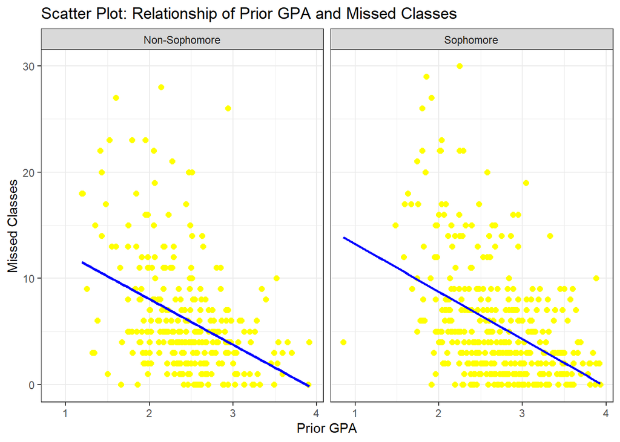

```r
df_soph <- df %>%
  mutate(soph = case_when(soph == "1" ~ "Sophomore",
                           soph == "0" ~ "Non-Sophomore"),
         soph = factor(soph)
              )

df_soph %>%
  ggplot(aes(priGPA, missed)) +
  geom_point(size = 2, color = "yellow")+
  geom_smooth(method = "lm", se = FALSE, color = "blue")+
  facet_wrap(~ soph)+
  theme_bw()+
  labs(
    title = "Scatter Plot: Relationship of Prior GPA and Missed Classes",
    x = "Prior GPA",
    y = "Missed Classes",

  )
```

# 3 Question 3: Understand barplots(dodge vs. stack. faceted)

## 3.1 3.1

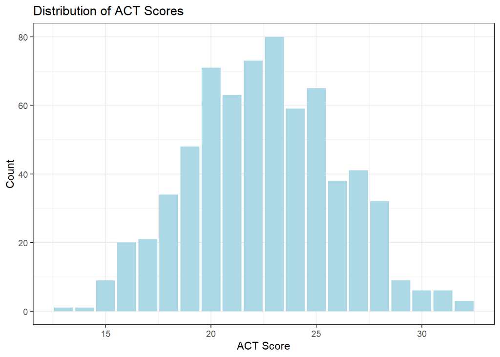

```r
df %>%
  ggplot(aes(x = ACT)) +
  geom_bar(fill = "lightblue") +
  labs(title = "Distribution of ACT Scores",
       x = "ACT Score", y = "Count") +
  theme_bw()
```

- *It is a normal distribution*

## 3.2 Dodge, Stack and Faceted Barplots

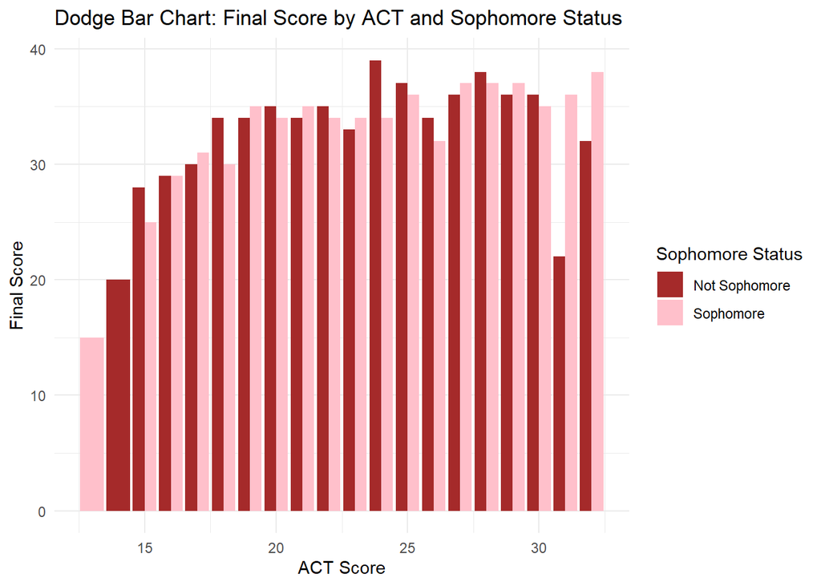

```r
# Recoding/Relabelling the Sophomore Column
df_soph <- df %>%
  mutate(label_soph = factor(soph,
                              levels = c(0, 1),
                              labels = c("Not Sophomore", "Sophomore")))

#Plotting a Stacked Bar Chart
ggplot(df_soph, aes(x = ACT, y = final, fill = label_soph)) +
geom_col(position = "dodge", width = 0.9) +
scale_fill_manual(values = c("Not Sophomore" = "brown", "Sophomore" = "pink")) +
  labs(title = "Dodge Bar Chart: Final Score by ACT and Sophomore Status",
       x = "ACT Score", y = "Final Score",
       fill = "Sophomore Status") +
  theme_minimal()
```

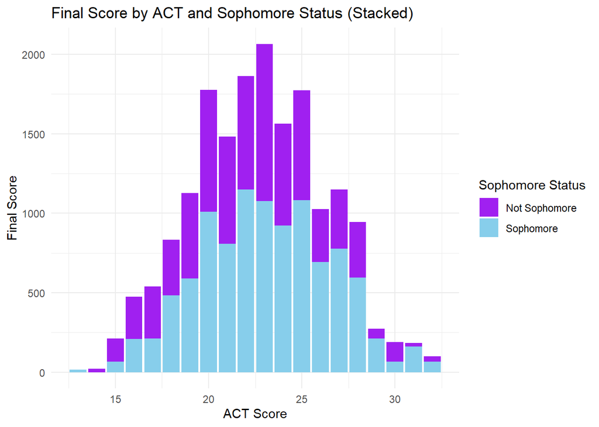

```r
#Plotting a Stacked Bar Chart
ggplot(df_soph, aes(x = ACT, y = final, fill = label_soph)) +
  geom_col(position = "stack", width = 0.9) +
  scale_fill_manual(values = c("Not Sophomore" = "purple", "Sophomore" = "skyblue")) +
  labs(title = "Final Score by ACT and Sophomore Status (Stacked)",
       x = "ACT Score", y = "Final Score",
       fill = "Sophomore Status") +
  theme_minimal()
```

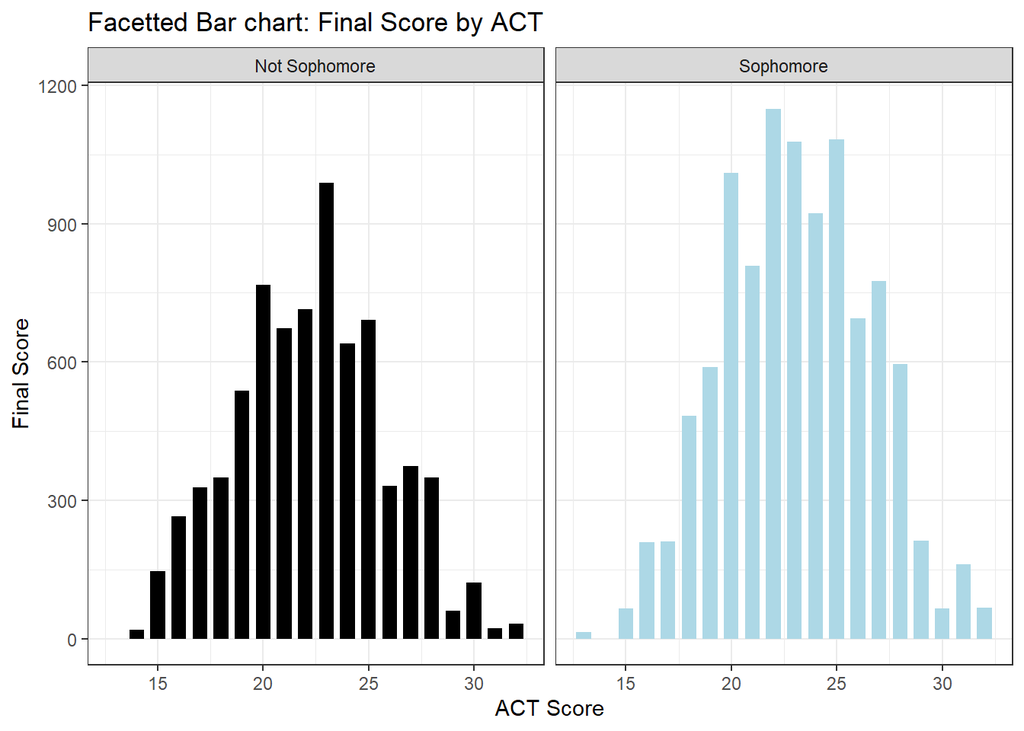

```r
#Plotting a Facetted Bar Chart
ggplot(df_soph, aes(x = ACT, y = final, fill = label_soph)) +
  geom_col(width = 0.7) +
  facet_wrap(~ label_soph) +
  scale_fill_manual(values = c("Not Sophomore" = "black", "Sophomore" = "lightblue")) +
  labs(title = "Facetted Bar chart: Final Score by ACT",
       x = "ACT Score", y = "Final Score") +
  theme_bw() +
  theme(legend.position = "none")
```

# 4 Question 4: Barplots with ACT averages

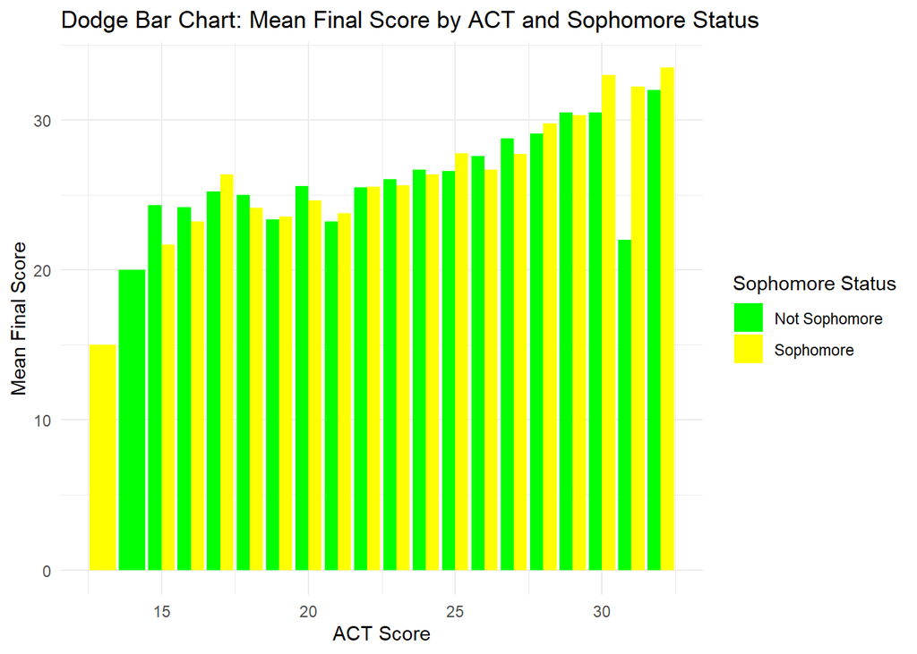

```r
#Aggregated Data: Dodge Bar Chart
df_aggregated <- df %>%
  mutate(soph_label = factor(soph, levels = c(0, 1), labels = c("Not Sophomore", "Sophomore"))) %>%
  group_by(ACT, soph_label) %>%
  summarise(mean_final = mean(final, na.rm = TRUE), .groups = "drop")
ggplot(df_aggregated, aes(x = ACT, y = mean_final, fill = soph_label)) +
  geom_col(position = position_dodge(width = 0.9), width = 0.9) +
  scale_fill_manual(values = c("Not Sophomore" = "green", "Sophomore" = "yellow")) +
  labs(title = "Dodge Bar Chart: Mean Final Score by ACT and Sophomore Status",
       x = "ACT Score", y = "Mean Final Score",
       fill = "Sophomore Status") +
  theme_minimal()
```

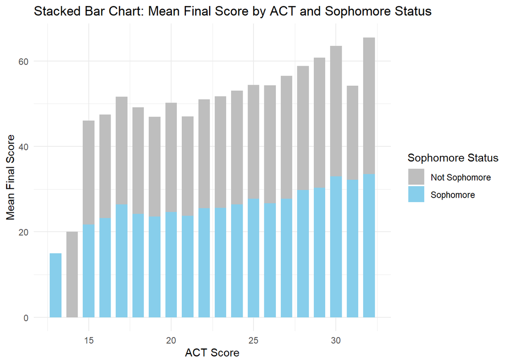

```r
#Aggregated Data: Stacked Bar Chart
ggplot(df_aggregated, aes(x = ACT, y = mean_final, fill = soph_label)) +
  geom_col(position = "stack", width = 0.7) +
  scale_fill_manual(values = c("Not Sophomore" = "grey", "Sophomore" = "skyblue")) +
  labs(title = "Stacked Bar Chart: Mean Final Score by ACT and Sophomore Status",
       x = "ACT Score", y = "Mean Final Score",
       fill = "Sophomore Status") +
  theme_minimal()
```

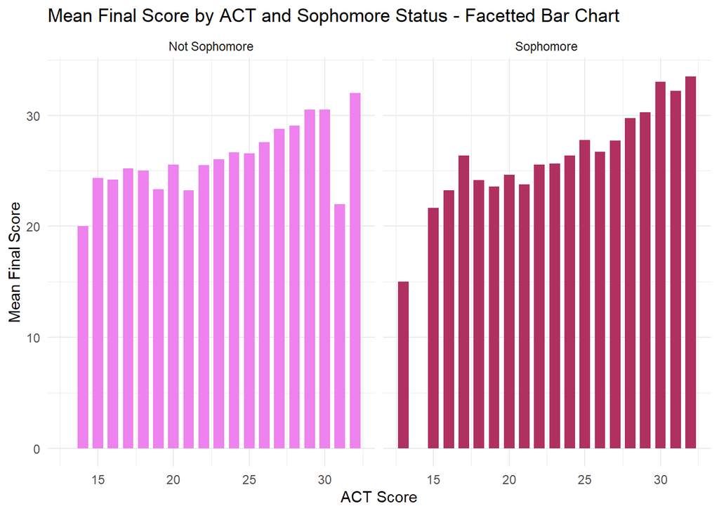

```r
# #Aggregated Data: Facetted Bar Chart
ggplot(df_aggregated, aes(x = ACT, y = mean_final, fill = soph_label)) +
  geom_col(width = 0.7) +
  facet_wrap(~ soph_label) +
  scale_fill_manual(values = c("Not Sophomore" = "violet", "Sophomore" = "maroon")) +
  labs(title = "Mean Final Score by ACT and Sophomore Status - Facetted Bar Chart ",
       x = "ACT Score", y = "Mean Final Score") +
  theme_minimal() +
  theme(legend.position = "none")
```

## 4.1 Carefully evaluate the three charts – dodged bar chart, stacked bar chart, or faceted bar chart. Pay attention to the value of the y variable too. Which one(s), if any, do you think accurately describe(s) the data? Why do you think so?

The dodged and faceted bar charts provide verification that the data aggregation was performed correctly, with the displayed means aligning perfectly with the values calculated from the underlying raw data.

## 4.2 Compare the dodged bar plot from Q3.2 with the dodged bar chart from Q4.2. Which chart would you trust and why?

- The dodged bar chart in 3.2 plots every individual final score, creating a crowded field of overlapping bars that obscures rather than illuminates. By displaying raw observations instead of group summaries, it fails to convey clear trends.
- Section 4.2 takes a more effective approach, aggregating final scores by ACT level and sophomore status to show average performance. This summary cuts through the noise, revealing central tendencies and enabling direct group comparisons. The result is a clear visualization of how ACT scores, final grades, and the moderating variable relate.
- In short, the mean-based chart is the superior choice—it distills the data into a trustworthy, informative summary that supports sound conclusions.

## 4.3 What would you say about the differences in the patterns of relationships between ACT and final scores shown in the sophomore and non-sophomore groups?

# 5 Question 5: Boxplot vs. Correct barplot

## 5.1 Boxplot

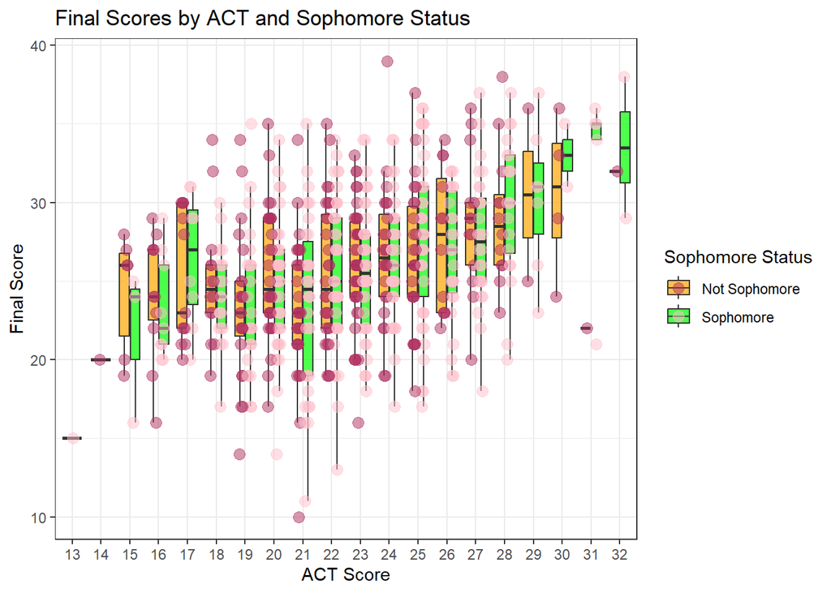

```r
ggplot(df_soph, aes(x = factor(ACT), y = final, fill = label_soph)) +
  geom_boxplot(outlier.shape = NA, alpha = 0.7) +
  geom_jitter(position = position_jitterdodge(jitter.width = 0.3, dodge.width = 0.6), aes(color = label_soph), alpha = 0.5, size = 3) +
  scale_fill_manual(values = c("Not Sophomore" = "orange", "Sophomore" = "green")) +
  scale_color_manual(values = c("Not Sophomore" = "maroon", "Sophomore" = "pink")) +
  labs(title = "Final Scores by ACT and Sophomore Status",
       x = "ACT Score", y = "Final Score",
       fill = "Sophomore Status", color = "Sophomore Status") +
  theme_bw()
```

## 5.2 Describe the differences between the box plot above and the barplot with you chose from Q4. Which one do you prefer and why

The bar plots from Question 4 facilitate a rapid comparison of central tendencies across groups. However, the boxplot presented in Question 5 offers a deeper level of insight by also displaying the distribution’s spread, median, and potential outliers. Consequently, my preference is for the boxplot with jitter, as it delivers a more complete and differentiated summary of the data.

## 5.3 What would you say about the differences in the patterns of relationships between ACT and final scores shown in the sophomore and non-sophomore groups?

# 6 Question 6: Impact of ACT on attendance, moderated by freshman status: Boxplot

## 6.1 Boxplot

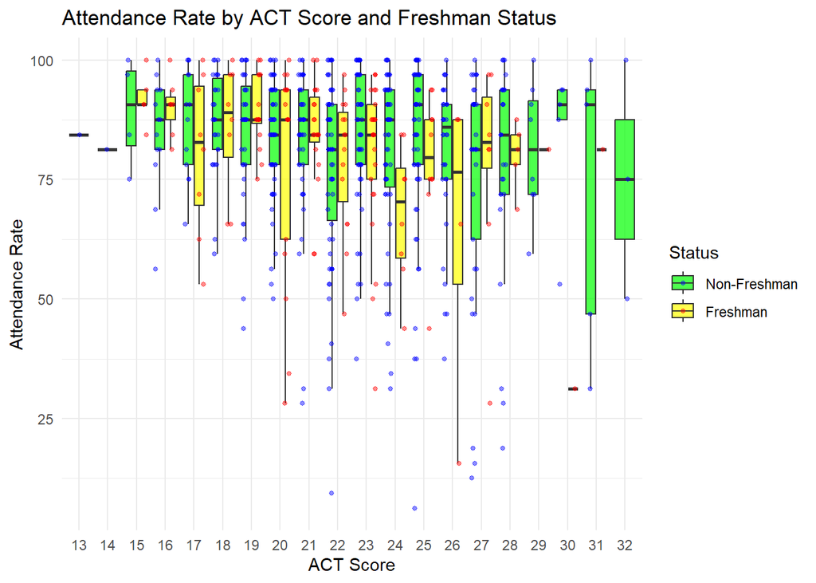

```r
df_fresh <- df %>%
  mutate(freshman_label = factor(frosh,
                                  levels = c(0, 1),
                                  labels = c("Non-Freshman", "Freshman")))

ggplot(df_fresh , aes(x = factor(ACT), y = atndrte, fill = freshman_label)) +
  geom_boxplot(outlier.shape = NA, alpha = 0.7) +
  geom_jitter(position = position_jitterdodge(jitter.width = 0.4, dodge.width = 1.0),
              aes(color = freshman_label), alpha = 0.45, size = 1.0) +
  scale_fill_manual(values = c("Non-Freshman" = "green", "Freshman" = "yellow")) +
  scale_color_manual(values = c("Non-Freshman" = "blue", "Freshman" = "red")) +
  labs(title = "Attendance Rate by ACT Score and Freshman Status",
       x = "ACT Score", y = "Attendance Rate",
       fill = "Status", color = "Status")+
  theme_minimal()
```

## 6.2 Is the relationship between x and y shown in the non-freshman group (denoted as “0” in the data) the same as that shown in the freshman group?

# 7 Question 7: Attendance by ACT, moderated by freshman status: Scatter Plot

## 7.1 Scatterplots

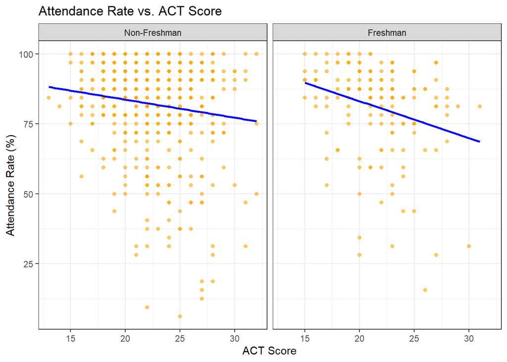

```r
ggplot(df_fresh, aes(x = ACT, y = atndrte)) +
  geom_point(alpha = 0.6, color = "orange") +
  geom_smooth(method = "lm", se = FALSE, color = "blue") +
  facet_wrap(~ freshman_label) +
  labs(title = "Attendance Rate vs. ACT Score",
       x = "ACT Score", y = "Attendance Rate (%)") +
  theme_bw()
```

## 7.2 In sum, describe what you found in the relationship between x and y and how the relationship pattern is different across the two freshman status groups.

# 8 Question 8: Correlations

## 8.1 Correlation plots

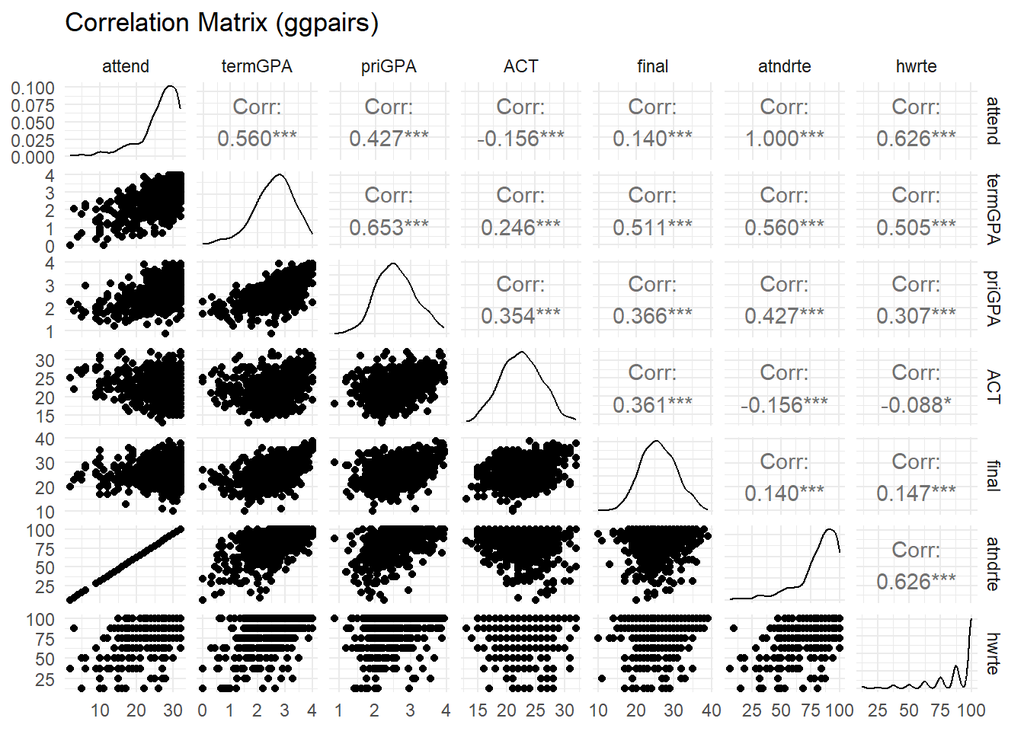

```r
#making a dataframe with only the required variables
var <- df %>%
  select(attend, termGPA, priGPA, ACT, final, atndrte, hwrte)

# drawing ggpairs
ggpairs(var, title = "Correlation Matrix (ggpairs)") +
  theme_minimal()
```

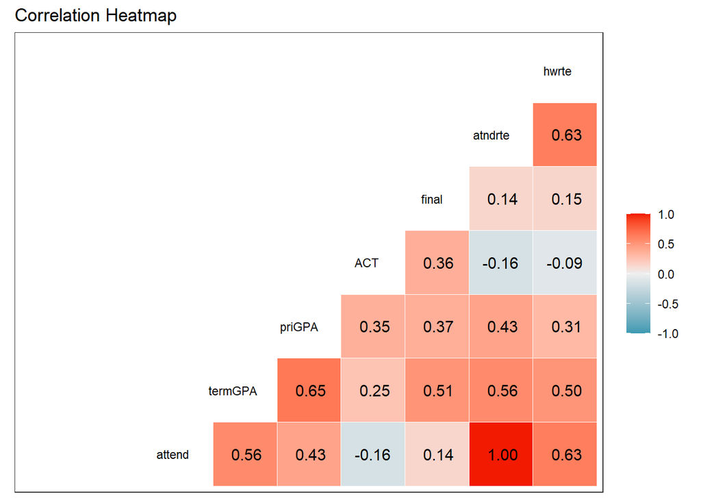

```r
#drawing ggcorr
ggcorr_plot <- ggcorr(var, label = TRUE,
                   label_round = 2,
                   hjust = 0.75,
                   size = 3,
                   layout.exp = 2) +
  labs(title = "Correlation Heatmap") +
  theme_bw()
print(ggcorr_plot)
```

## 8.2 Which pair of variables has the highest positive correlation? What is the correlation statistic? Does it make sense? why or why not. Which sets of variables has the next highest correlation?

```r
# Correlation matrix formulation
correlation_matrix <- cor(var, use = "complete.obs")
print(correlation_matrix)
```

```
            attend   termGPA    priGPA        ACT     final    atndrte
attend   1.0000000 0.5384264 0.4196933 -0.1336442 0.1480643  1.0000000
termGPA  0.5384264 1.0000000 0.6542621  0.2732598 0.5215440  0.5384264
priGPA   0.4196933 0.6542621 1.0000000  0.3681972 0.3710426  0.4196933
ACT     -0.1336442 0.2732598 0.3681972  1.0000000 0.3618229 -0.1336442
final    0.1480643 0.5215440 0.3710426  0.3618229 1.0000000  0.1480643
atndrte  1.0000000 0.5384264 0.4196933 -0.1336442 0.1480643  1.0000000
hwrte    0.6259695 0.5048751 0.3072889 -0.0884341 0.1465651  0.6259695
             hwrte
attend   0.6259695
termGPA  0.5048751
priGPA   0.3072889
ACT     -0.0884341
final    0.1465651
atndrte  0.6259695
hwrte    1.0000000
```

```r
# Extract upper triangle of the matrix
upper_tri <- upper.tri(correlation_matrix)
upper_cors <- correlation_matrix[upper_tri]
max_corr <- max(upper_cors)

max_index <- which(correlation_matrix == max_corr & upper_tri, arr.ind = TRUE)[1, ]
var_1 <- rownames(correlation_matrix)[max_index[1]]
var_2 <- colnames(correlation_matrix)[max_index[2]]

# Displaying the result
print(paste("Highest correlation:", max_corr, "between", var_1, "and", var_2))
```

```
[1] "Highest correlation: 1 between attend and atndrte"
```

## 8.3 The correlations among variables give us insights into what students should do to improve their GPA (termGPA and priGPA). Accoridng to the data, between attendance rate (“atndrte”) and the rate of homework turned in (“hwrte”), which is a moreeffective way to improve GPA’s? (note you don’t need to test differences in correlations; use eyeballing)

```r
# Getting attendance rate and howework turn in rate, termGPA and priGPA relationship
cor(var[, c("atndrte", "hwrte")], var[, c("termGPA", "priGPA")], use = "complete.obs")
```

```
          termGPA    priGPA
atndrte 0.5384264 0.4196933
hwrte   0.5048751 0.3072889
```

Attendance rate correlates more strongly with both term GPA and prior GPA than submitting homework does. From this we conclude that attending classes often may better ones grades than submitting homework.

# 9 Question 9: Scatter plot with regression line for the Impact of priGPA on termGPA

## 9.1 A scatter plot with a linear regression line

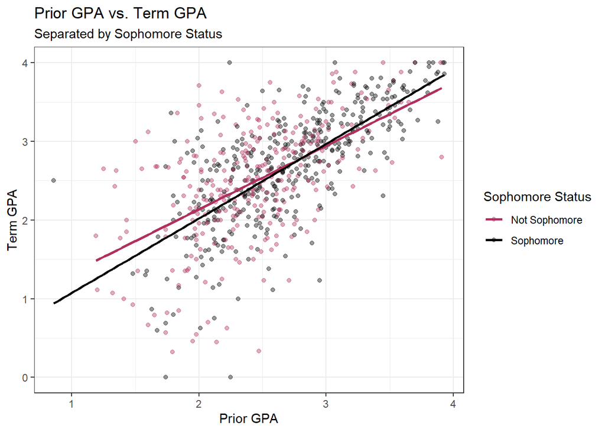

```r
df_soph <- df %>%
  mutate(soph_label = factor(soph,
                              levels = c(0, 1),
                              labels = c("Not Sophomore", "Sophomore")))

scatter_plt <- ggplot(df_soph, aes(x = priGPA, y = termGPA, color = soph_label)) +
  geom_point(alpha = 0.4) +
  geom_smooth(method = "lm", se = FALSE) +
  scale_color_manual(values = c("Not Sophomore" = "maroon", "Sophomore" = "black"))+
  labs(title = "Prior GPA vs. Term GPA",
       subtitle = "Separated by Sophomore Status",
       x = "Prior GPA", y = "Term GPA",
       color = "Sophomore Status") +
  theme_bw()

# Print the plot
print(scatter_plt)
```

## 9.2 *What can you tell about the strengths of the relationships between priGPA and termGPA?*

# 10 *Question 10: Interactive Plot & Save the plot from Question 9*

## 10.1 *Use the function “ggplotly()” and pass the “plot” through it. Move your cursor over the plots to feel the interactiveness. Also, label your plot with the variable “soph”.*

```r
#making the previous scatter plot (question 9) into an interactive plot
interactive_plt <- ggplotly(scatter_plt, tooltip = c("x", "y", "color"))
interactive_plt
```

[interactive chart not shown]

## 10.2 Save your plot created in Question 8 as an image file with the following name:“myplot.png” and prepare to submit it in the next step.

```r
#Saving the ggcorr_plt from question 8 into a png
ggsave("myplot.png", plot = ggcorr_plot, width = 10, height = 8 , dpi = 400)
```